# Investigating the relationship between wind and other weather variables.

by Kate Supremacy: Connor, Kate, Ruth, Torgua & Kate

2024-12-01

## Research Question

Our research question is: Investigating the relationship between wind and other weather variables. We chose this focus because during our exploratory data analysis we noticed strong patterns and correlation between the wind chill and direction with other variables such as heat index and temperature.

## Data

Our dataset is from the National Centres for Environmental Information Climate Data, specifically the hourly normals for the city of New York in the year 2010, measured from JFK International Airport. These normals contain measurements of various meteorological parameters.

We selected this dataset because it had a large number of variables for each observation, therefore there should be some interesting correlations. The dataset also contained both numerical and categorical data so we could carry out a range of analyses on it.

The dataset came with documentation for all normals datasets, which explained the values in the dataset, special values and their meanings and how derived variables were calculated.

Explaining our variables: - The cloud analysis variables describe the percentage of different types of cloud coverage. - For temperature variables, the dew point represents the moisture/humidity of the air, the heat index indicates how hot it feels to a human observer, and wind chill is the effect the wind has on temperature, temperature is self explanatory. - Wind variables are separated into first and second winds, then into wind speed and direction. - Time variables state the date and time of each observation.

## Findings

### Methods

To import and clean our data we used tidyverse/dplyr functions in order to read a csv file as a data frame, rename and transform columns.

We continued to use this tool set in our exploratory data analysis: creating frequency tables and making summaries of different groups of data. Particularly we used a range of ggplot graph types to create bar charts, histograms, and scatter graphs.

Then we went on to create models using the tidymodels package: creating training and testing data frames, creating recipes, specifying models and combining these to form workflows which we then fitted to the training data to make predictions for the testing data.  
Following the creation of our models we then analysed their performance. For our logistic models this was done by plotting ROC curves and calculating the area underneath them to assess the fit of the model on the testing data. For linear regressions we calculated R-squared and RMSE, along with creating residual plots, in order to see how effectively a linear model fit the data.

### Exploratory Data Analysis

We began by creating some frequency tables of our key variables to understand them better.

```r
nyweather %>%
  count(wind_main_dir) %>% # count frequency of each main direction
  arrange(desc(n)) # order starting with highest frequency
```

```
## # A tibble: 7 × 2
##   wind_main_dir     n
##           <dbl> <int>
## 1             8  3133
## 2             5  2696
## 3             6  1410
## 4             2   614
## 5             7   613
## 6             1   291
## 7             3     2
```

```r
nyweather %>%
  count(wind_2nd_dir) %>% # count frequency of each secondary direction
  arrange(desc(n)) # order starting with highest frequency
```

```
## # A tibble: 8 × 2
##   wind_2nd_dir     n
##          <dbl> <int>
## 1            7  2317
## 2            8  1554
## 3            6  1371
## 4            1  1245
## 5            5   794
## 6            4   763
## 7            2   676
## 8            3    39
```

From this we can see that the most common wind directions are a northwest main direction and a west secondary direction, and the least common for both is east.

We then created some bar charts to see how our key variables changed throughout the year.

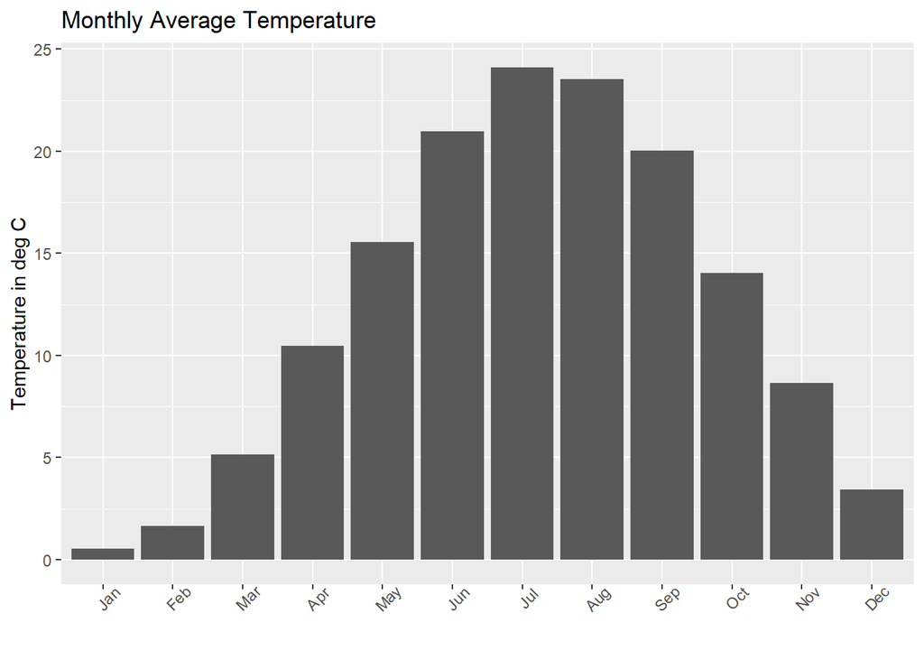

```r
nyweather_separate <- nyweather %>%
  separate(day, into = c("month", "day"), sep = "-") %>% # separate the date into month and day
  mutate(
    month = as.numeric(month),
    day = as.numeric(day),
    name_month = factor(month.abb[month], levels = month.abb)
  ) # make these numeric values and create the factor name_month

nyweather_monthly <- nyweather_separate %>%
  group_by(name_month) %>% # group observations by month
  summarize(monthly_temp_avg = mean(temp_avg),
            monthly_dewp_avg = mean(dewp_avg),
            monthly_wind_chill_avg = mean(wind_chill_avg),
            monthly_wind_spd_avg = mean(wind_spd_avg)) # find monthly averages for temperature, dew point, wind chill and wind speed

nyweather_monthly %>%
  ggplot(aes(x = name_month, y = monthly_temp_avg)) + # set month to x axis and temperature to y axis
  geom_bar(stat = "identity") + # create bar chart
  labs(title = "Monthly Average Temperature",
       x = "",
       y = "Temperature in deg C") + # label graph
  theme(axis.text.x = element_text(angle = 45)) # tilt x axis text so easier to read
```

This first graph shows the spread of temperature over the year, which increases over the summer months then decreases in winter as you would expect.

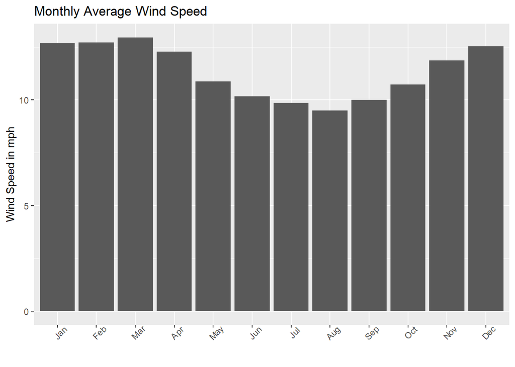

```r
nyweather_monthly %>%
  ggplot(aes(x = name_month, y= monthly_wind_spd_avg)) +
  geom_bar(stat = "identity") +
  labs(title = "Monthly Average Wind Speed",
       x = "",
       y = "Wind Speed in mph") +
  theme(axis.text.x = element_text(angle = 45))
```

The wind speed chart shows that winds have higher speeds from November to April. This is the same period of lower temperatures, suggesting there may be a correlation between these variables.

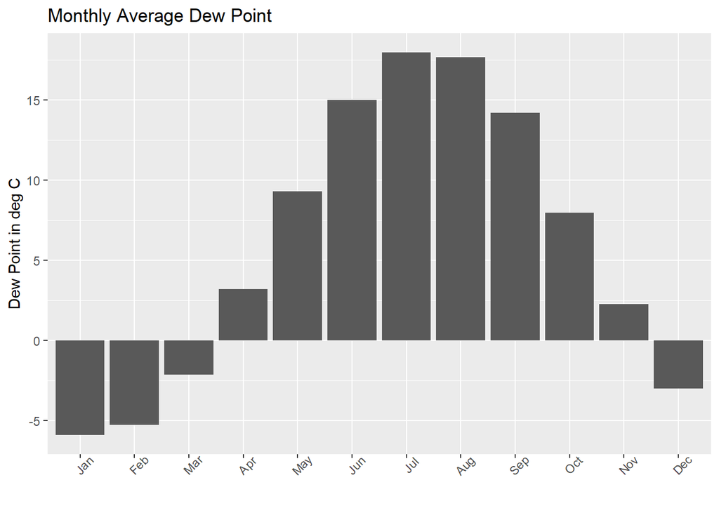

```r
nyweather_monthly %>%
  ggplot(aes(x = name_month, y= monthly_dewp_avg)) +
  geom_bar(stat = "identity") +
  labs(title = "Monthly Average Dew Point",
       x = "",
       y = "Dew Point in deg C") +
  theme(axis.text.x = element_text(angle = 45))
```

The dew point graph has a similar shape to the one for temperature, suggesting there may be a correlation between these variables. From research long periods of a high dew point implies prolonged humidity.

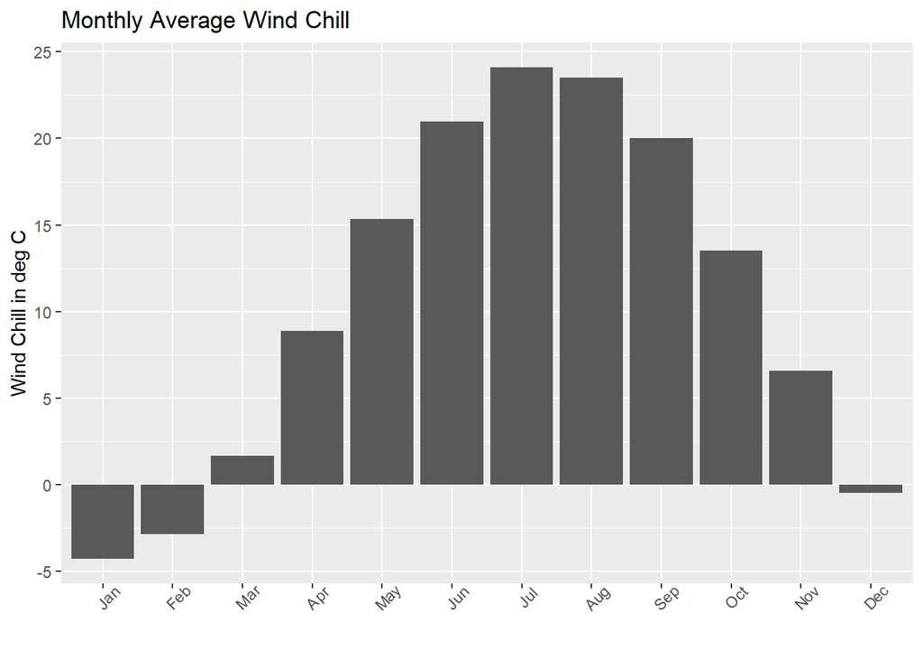

```r
nyweather_monthly %>%
  ggplot(aes(x = name_month, y= monthly_wind_chill_avg)) +
  geom_bar(stat = "identity") +
  labs(title = "Monthly Average Wind Chill",
       x = "",
       y = "Wind Chill in deg C") +
  theme(axis.text.x = element_text(angle = 45))
```

We also created some histograms to get a sense of the spread of our data values.

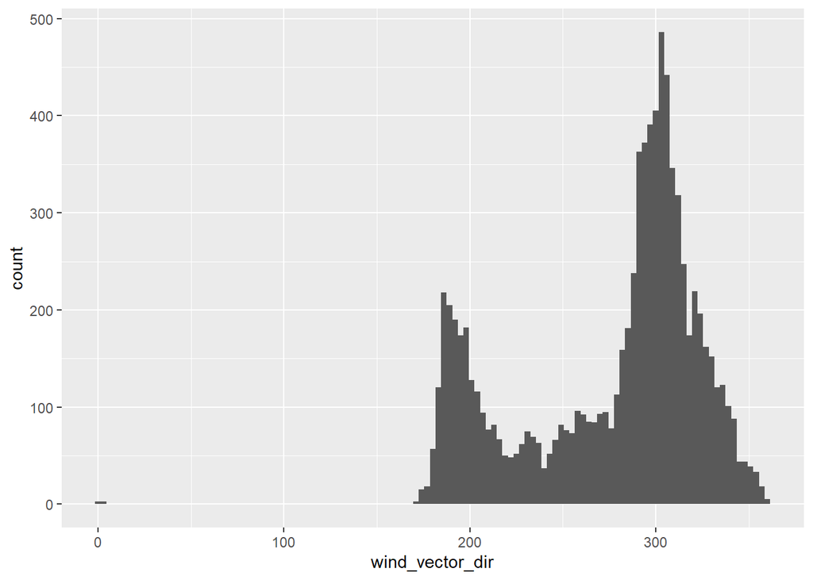

```r
nyweather %>%
  ggplot(aes(wind_vector_dir)) + # set variable to plot
  geom_histogram(binwidth = 3)  # create histogram and set width of bins to 3
```

The primary wind vector direction is left skewed, with the majority of values between 200-350 degrees which agrees with our frequency tables.

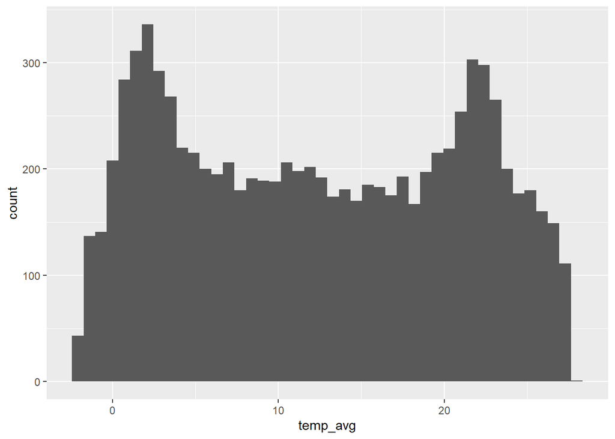

```r
nyweather %>%
  ggplot(aes(temp_avg)) +
  geom_histogram(binwidth = 0.7)
```

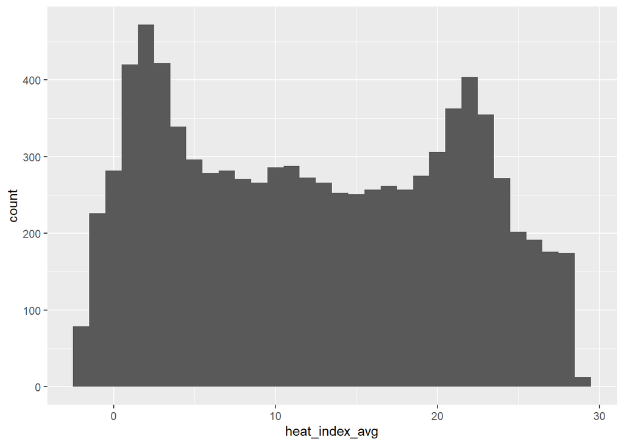

```r
nyweather %>%
  ggplot(aes(heat_index_avg)) +
  geom_histogram(binwidth = 1)
```

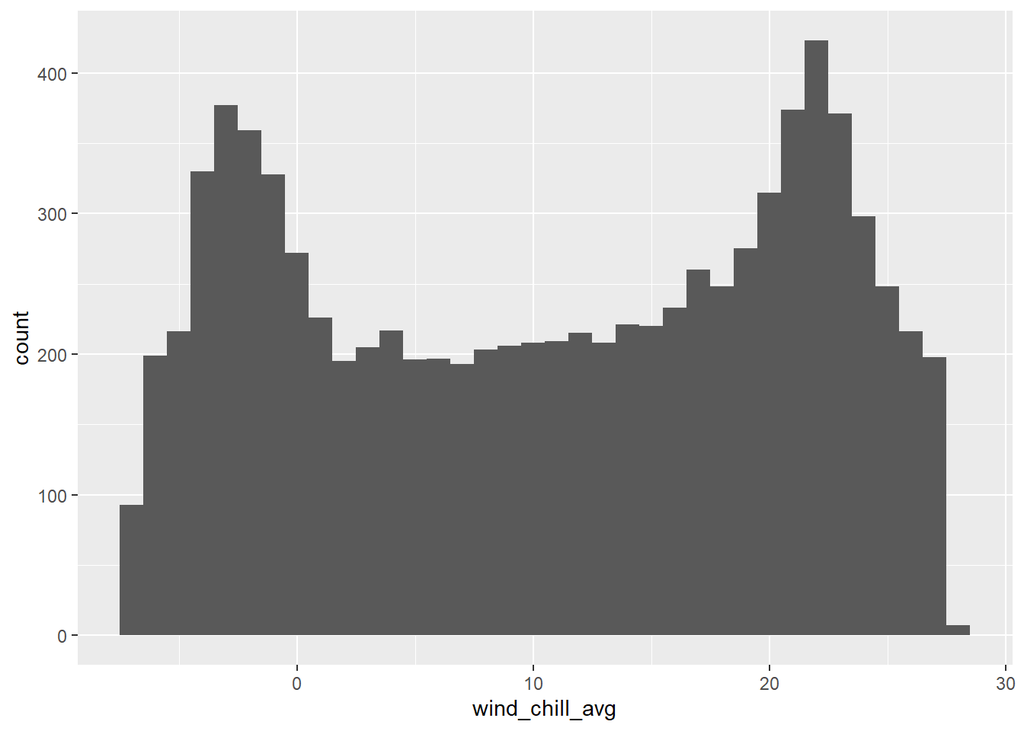

```r
nyweather %>%
  ggplot(aes(wind_chill_avg)) +
  geom_histogram(binwidth = 1)
```

These histograms for temperature average, heat index average and wind chill average all have a similar shape, suggesting these variables are correlated which could help to answer our investigation question.

Finally we made some scatter graphs to assess correlation between certain variables before constructing our models.

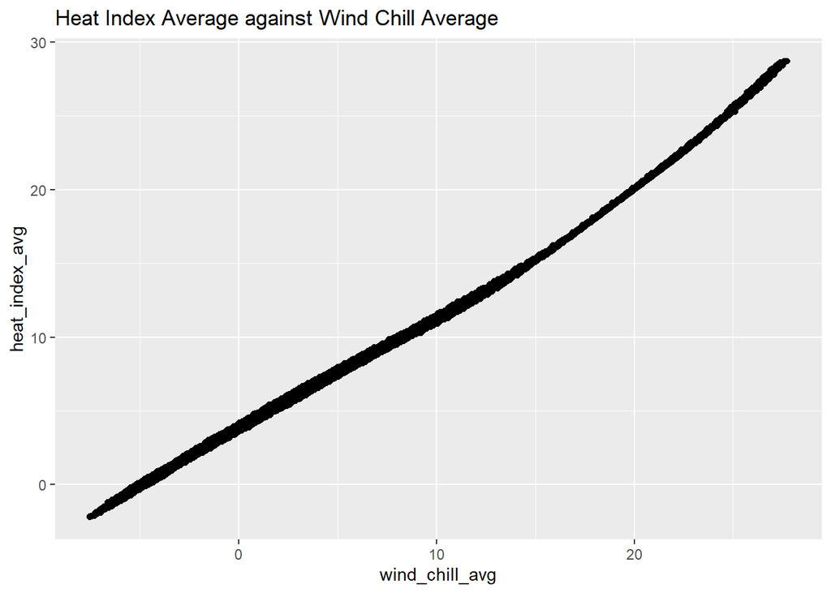

```r
nyweather %>%
  ggplot(aes(x = wind_chill_avg, y = heat_index_avg)) + # set x and y varibles
  geom_jitter() + # create jitter (scatter) graph
  labs(title = "Heat Index Average against Wind Chill Average") # label graph
```

This shows there is a strong linear correlation between heat index mean and wind chill. Since the calculation for heat index does not include wind chill, there must be another factor affecting both.

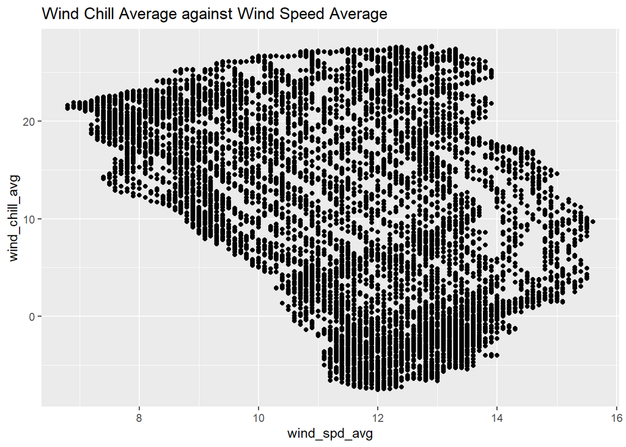

```r
nyweather %>%
  ggplot(aes(x = wind_spd_avg, y = wind_chill_avg)) +
  geom_point() +
  labs(title = "Wind Chill Average against Wind Speed Average")
```

We can observe that there is very little correlation between wind speed and wind chill therefore wind speed is likely not the variable causing this relationship between heat index and wind chill.

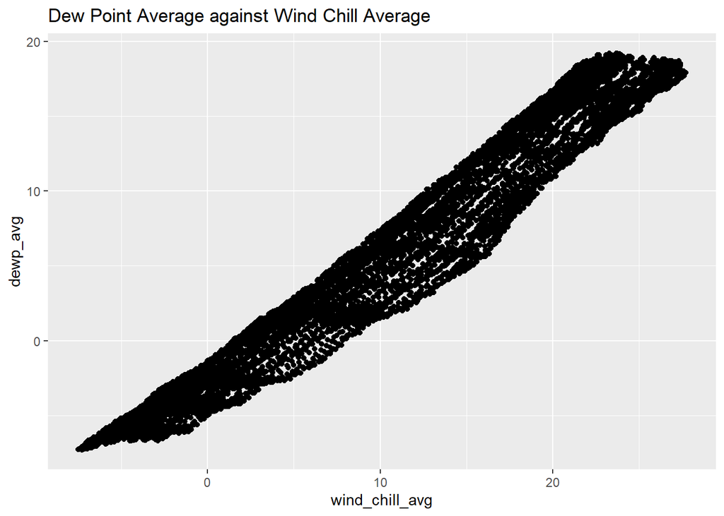

```r
nyweather %>%
  ggplot(aes(x = wind_chill_avg, y = dewp_avg)) +
  geom_jitter() +
  labs(title = "Dew Point Average against Wind Chill Average")
```

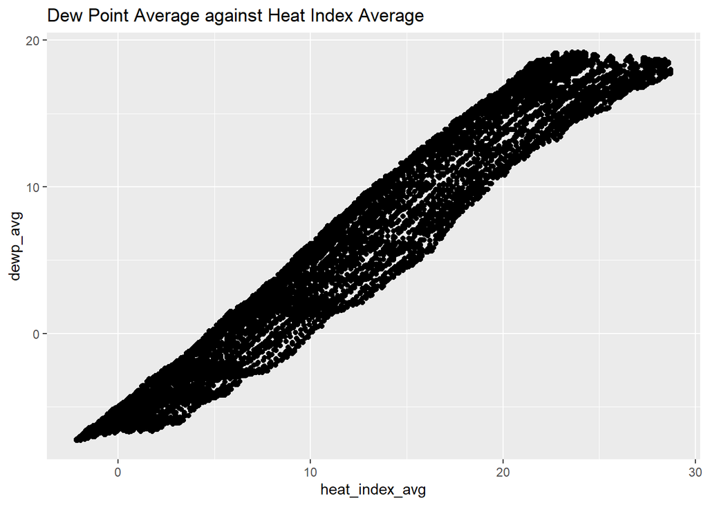

```r
nyweather %>%
  ggplot(aes(x = heat_index_avg, y = dewp_avg)) +
  geom_point() +
  labs(title = "Dew Point Average against Heat Index Average")
```

We can observe that there is a strong correlation between dew point and both heat index and wind chill, suggesting that humidity is the reason these two variables are so strongly correlated. This makes sense since increasing humidity will cause the effect of water evaporating on wind chill to be stronger.

### Linear regression

From the scatter graphs we decided to further investigate the strong correlation between heat index average and wind chill average.

```r
set.seed(1234)
nyweather_split_1 <- initial_split(nyweather) # create initial split
nyweather_train_1 <- training(nyweather_split_1) # make training dataset
nyweather_test_1  <- testing(nyweather_split_1) # make testing dataset

wind_heat_mod_1 <- linear_reg() %>%
  set_engine("lm") # create model

wind_heat_rec_1 <- recipe(
  wind_chill_avg ~ heat_index_avg,
  data = nyweather_train_1) # create recipe

wind_heat_wflow_1 <- workflow() %>%
  add_model(wind_heat_mod_1) %>%
  add_recipe(wind_heat_rec_1) # add each to a workflow

wind_heat_fit_1 <- wind_heat_wflow_1 %>%
  fit(data = nyweather_train_1) # fit the training data

tidy(wind_heat_fit_1) # display the regression parameters
```

```
## # A tibble: 2 × 5
##   term           estimate std.error statistic p.value
##   <chr>             <dbl>     <dbl>     <dbl>   <dbl>
## 1 (Intercept)       -4.19   0.0171      -246.       0
## 2 heat_index_avg     1.19   0.00113     1058.       0
```

```r
wind_heat_pred_1 <- predict(wind_heat_fit_1, nyweather_test_1) %>%
  bind_cols(nyweather_test_1 %>% select(wind_chill_avg, heat_index_avg)) # create predictions table

rsq(wind_heat_pred_1, truth = wind_chill_avg, estimate = .pred) # calculate R-squared
```

```
## # A tibble: 1 × 3
##   .metric .estimator .estimate
##   <chr>   <chr>          <dbl>
## 1 rsq     standard       0.994
```

```r
rmse(wind_heat_pred_1, truth = wind_chill_avg, estimate = .pred) # calculate RMSE
```

```
## # A tibble: 1 × 3
##   .metric .estimator .estimate
##   <chr>   <chr>          <dbl>
## 1 rmse    standard       0.793
```

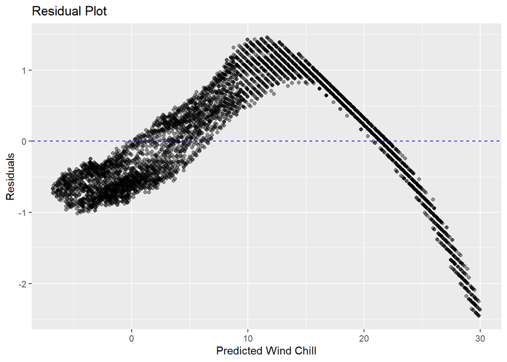

```r
wind_heat_fit_aug_1 <- augment(wind_heat_fit_1, nyweather_train_1) %>%
  mutate(res_cat = ifelse(.resid > 0, TRUE, FALSE)) # create augmented table of fitted values and actual values

ggplot(wind_heat_fit_aug_1, mapping = aes(x = .pred, y = .resid)) + # create residual plot
  geom_point(alpha = 0.4) + # set transparency of points to 0.4
  geom_hline(yintercept = 0, # add reference line
             color = "blue", # set colour to blue
             lty = "dashed") + # make line dashed
  labs(title = "Residual Plot",
       x = "Predicted Wind Chill",
       y = "Residuals") # label graph
```

Initially fitting a linear model appeared quite successful, with an R-squared value close to 1. The RMSE value was 0.79 and the range of wind chill was 35.1, therefore the percentage error is approximately 2%.

However when we plotted the residuals, there was a clear relationship. This indicated that some other variable was impacting this correlation and that a linear model might not be optimal.

We then considered whether a log transformation would be useful in the issues with residuals however the data was not right skewed as seen in the histogram earlier.

We decided to create a multivariate linear model to see if that was better at predicting wind chill with less of a pattern in the residuals.

```r
wind_heat_mod_2 <- linear_reg() %>%
  set_engine("lm")

wind_heat_rec_2 <- recipe(
  wind_chill_avg ~ heat_index_avg + temp_avg + cloud_ovrcst_pct + wind_vector_spd,
  data = nyweather_train_1
) %>%
  step_dummy(all_nominal(), -all_outcomes()) # create dummy variables for all predictor variables and not of outcome variables

wind_heat_wflow_2 <- workflow() %>%
  add_model(wind_heat_mod_2) %>%
  add_recipe(wind_heat_rec_2)

wind_heat_fit_2 <- wind_heat_wflow_2 %>%
  fit(data = nyweather_train_1)

wind_heat_fit_2
```

```
## ══ Workflow [trained] ══════════════════════════════════════════════════════════
## Preprocessor: Recipe
## Model: linear_reg()
##
## ── Preprocessor ────────────────────────────────────────────────────────────────
## 1 Recipe Step
##
## • step_dummy()
##
## ── Model ───────────────────────────────────────────────────────────────────────
##
## Call:
## stats::lm(formula = ..y ~ ., data = data)
##
## Coefficients:
##      (Intercept)    heat_index_avg          temp_avg  cloud_ovrcst_pct
##         -4.04932          -1.51409           2.73254           0.01192
##  wind_vector_spd
##         -0.17189
```

```r
wind_heat_pred_2 <- predict(wind_heat_fit_2, nyweather_test_1) %>%
  bind_cols(nyweather_test_1 %>%
              select(wind_chill_avg,
                     heat_index_avg,
                     temp_avg,
                     cloud_ovrcst_pct,
                     wind_vector_spd))

rsq(wind_heat_pred_2, truth = wind_chill_avg, estimate = .pred)
```

```
## # A tibble: 1 × 3
##   .metric .estimator .estimate
##   <chr>   <chr>          <dbl>
## 1 rsq     standard       0.998
```

```r
rmse(wind_heat_pred_2, truth = wind_chill_avg, estimate = .pred)
```

```
## # A tibble: 1 × 3
##   .metric .estimator .estimate
##   <chr>   <chr>          <dbl>
## 1 rmse    standard       0.424
```

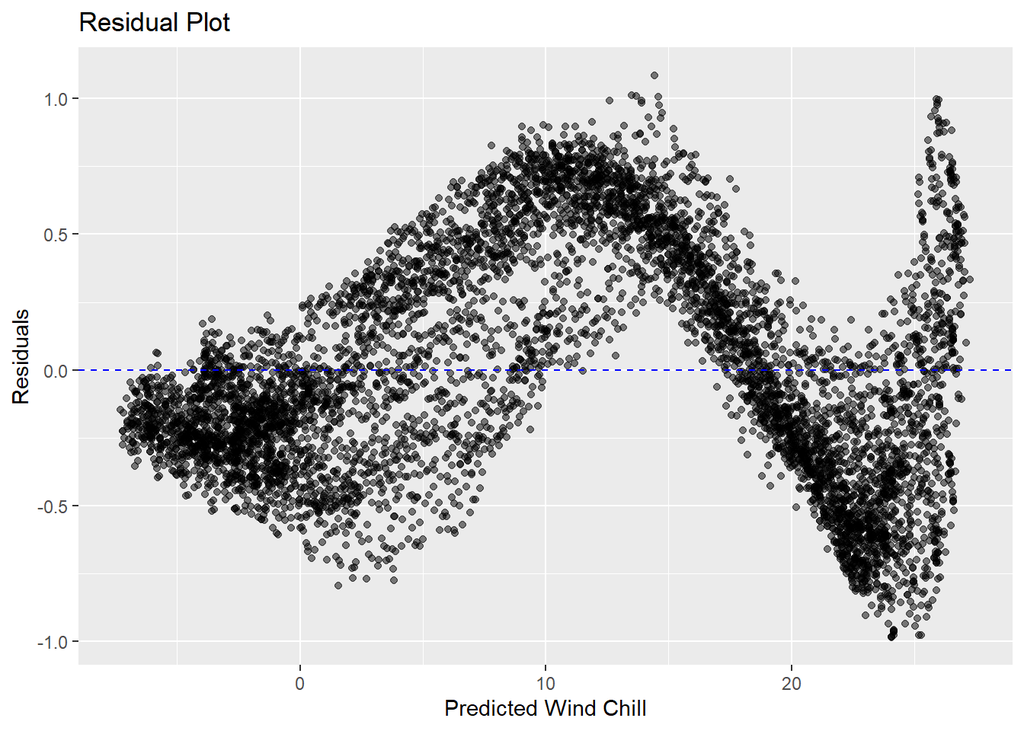

```r
wind_heat_fit_aug_2  <- augment(wind_heat_fit_2, nyweather_train_1) %>%
  mutate(res_cat = ifelse(.resid > 0, TRUE, FALSE))

ggplot(wind_heat_fit_aug_2, mapping = aes(x = .pred, y = .resid)) +
  geom_point(alpha = 0.5) +
  geom_hline(yintercept = 0,
             color = "blue",
             lty = "dashed") +
  labs(title = "Residual Plot",
       x = "Predicted Wind Chill",
       y = "Residuals")
```

The R-squared value was slightly closer to one but this doesn’t indicate whether the model is better as more variables were added. The RMSE was smaller at only 0.42; however this was already a small percentage of the range and therefore this small difference might not justify the added complexity of the multivariate model (Occam’s razor). The plot of the residuals of the multivariate linear model also had a clear pattern so this model didn’t resolve the main issue.

### Logistic regression

Through the histograms and frequency tables of our exploratory data analysis we noticed that wind came most often from the west direction. We decided to investigate this further by creating a logistic model.

```r
nyweather <- nyweather %>%
  mutate(
    wind_main_west = case_when(
      wind_main_dir == "6" ~ "yes",
      wind_main_dir == "7" ~ "yes",
      wind_main_dir == "8" ~ "yes",
      TRUE ~ "no"
    ),
    wind_main_west = fct_relevel(wind_main_west, "no", "yes")
  )

set.seed(1234)
nyweather_split_2 <- initial_split(nyweather)
nyweather_train_2 <- training(nyweather_split_2)
nyweather_test_2  <- testing(nyweather_split_2)

wind_dir_rec_1 <- recipe(
  wind_main_west ~ temp_avg,
  data = nyweather_train_2)

wind_dir_mod_1 <- logistic_reg() %>%
  set_engine("glm")

wind_dir_wflow_1 <- workflow() %>%
  add_model(wind_dir_mod_1) %>%
  add_recipe(wind_dir_rec_1)

wind_dir_fit_1 <- wind_dir_wflow_1 %>%
  fit(data = nyweather_train_2)

tidy(wind_dir_fit_1)
```

```
## # A tibble: 2 × 5
##   term        estimate std.error statistic p.value
##   <chr>          <dbl>     <dbl>     <dbl>   <dbl>
## 1 (Intercept)    2.63    0.0674       39.0       0
## 2 temp_avg      -0.170   0.00424     -40.1       0
```

Our first model used the average temperature variable to predict whether the wind direction was in the west direction or not. We found that as the average temperature increases, the logic of the probability decreases, and therefore the probability that the wind will be in the west direction decreases. This makes sense as it would be coming over the Atlantic ocean.

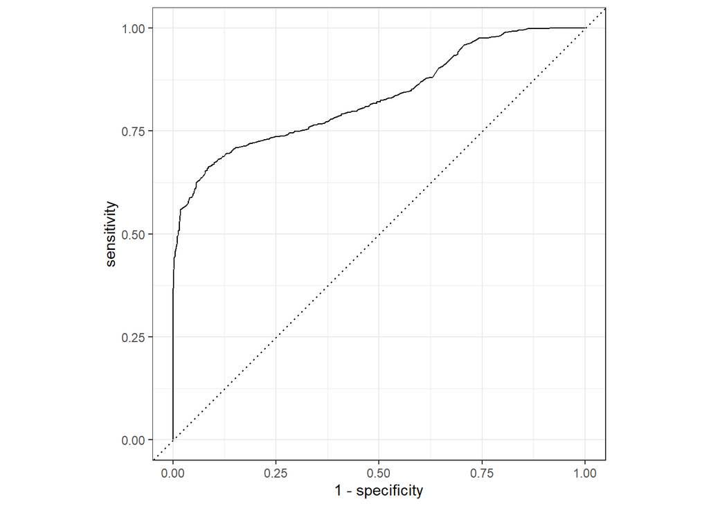

```r
wind_dir_pred_1 <- predict(wind_dir_fit_1, nyweather_test_2, type = "prob") %>%
  bind_cols(nyweather_test_2)

wind_dir_pred_1 %>%
  roc_curve(
    truth = wind_main_west,
    .pred_yes,
    event_level = "second") %>%
  autoplot() # plot ROC curve
```

```r
wind_dir_pred_1 %>%
  roc_auc(
    truth = wind_main_west,
    .pred_yes,
    event_level = "second"
  ) # find area under the curve
```

```
## # A tibble: 1 × 3
##   .metric .estimator .estimate
##   <chr>   <chr>          <dbl>
## 1 roc_auc binary         0.831
```

The ROC area is 0.83 which is somewhat close to one suggesting that the model is relatively good at predicting whether the wind is in the west direction or not.

We decided to try adding variables to this logistic model to see if we could improve it.

```r
wind_dir_rec_2 <- recipe(
  wind_main_west ~ temp_avg + heat_index_avg + wind_chill_avg,
  data = nyweather_train_2
  ) %>%
  step_dummy(all_nominal(), -all_outcomes())

wind_dir_mod_2 <- logistic_reg() %>%
  set_engine("glm")

wind_dir_wflow_2 <- workflow() %>%
  add_model(wind_dir_mod_2) %>%
  add_recipe(wind_dir_rec_2)

wind_dir_fit_2 <- wind_dir_wflow_2 %>%
  fit(data = nyweather_train_2)

tidy(wind_dir_fit_2)
```

```
## # A tibble: 4 × 5
##   term           estimate std.error statistic   p.value
##   <chr>             <dbl>     <dbl>     <dbl>     <dbl>
## 1 (Intercept)       -5.26    0.302      -17.5 3.42e- 68
## 2 temp_avg           7.77    0.432       18.0 2.41e- 72
## 3 heat_index_avg    -5.57    0.370      -15.0 4.57e- 51
## 4 wind_chill_avg    -1.95    0.0760     -25.7 1.72e-145
```

The interpretation of this model is slightly more complex, interestingly by adding variables, on average the mean temperature has the opposite effect on the probability of the wind direction being west.

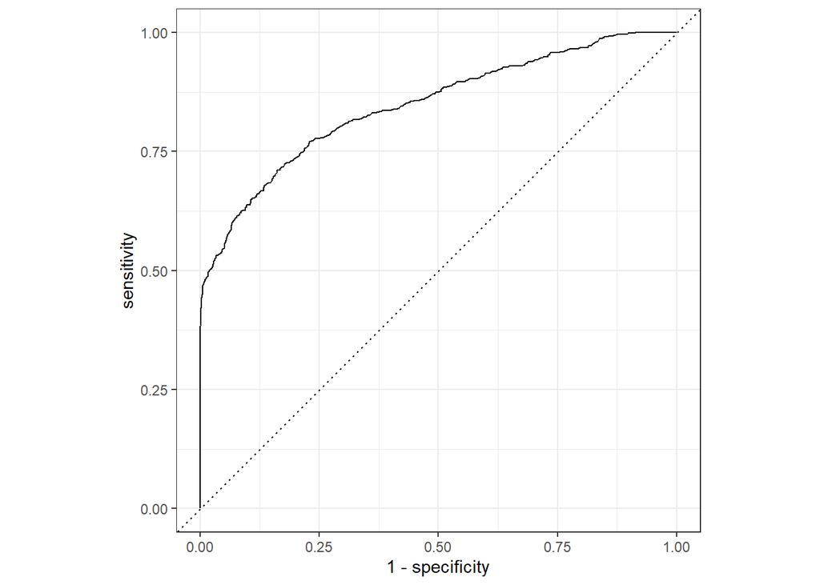

```r
wind_dir_pred_2 <- predict(wind_dir_fit_2, nyweather_test_2, type = "prob") %>%
  bind_cols(nyweather_test_2)

wind_dir_pred_2 %>%
  roc_curve(
    truth = wind_main_west,
    .pred_yes,
    event_level = "second") %>%
  autoplot()
```

```r
wind_dir_pred_2 %>%
  roc_auc(
    truth = wind_main_west,
    .pred_yes,
    event_level = "second")
```

```
## # A tibble: 1 × 3
##   .metric .estimator .estimate
##   <chr>   <chr>          <dbl>
## 1 roc_auc binary         0.847
```

The ROC area is slightly closer to one at 0.85 but not by much. Again like the linear model it might be that the slightly better performance of the multivariate model might not be favourable over the much simpler model.

### Answering our question

Investigating the relationships between wind and other weather variables has been a success, we found relationships and created models. We have established there is a clear relationship between winds from the west and cooler temperatures.

Although we did not find an appropriate model for the relationship between heat index and wind chill it was clear that there is a positive correlation between the two.

### Evaluation

WWW  
- We worked well as a team, splitting up the work equally and making sure that people were doing analysis techniques that they felt confident in. During workshops we also carried out pair programming techniques to reduce merger errors.  
- We coded clearly, using clear variable names and adding lots of comments to our code to explain what we were doing. We also worked in different R code chunks of the investigation.rmd document to clearly show the different sections of data analysis. - We clearly documented the progress of our project using a shared google document.

EBI  
- We could have looked into different cloud scatter patterns as part of our investigation and how these were affected by wind. - We could have carried out cross validation to estimate how well the model would have worked in practice, and then extended our inferences from our modelling by using bootstrapping and constructing a confidence interval.  
- We could have added precipitation records from this time period to our data and analysed any correlation between this and wind.

Word count: 1618

## References

Arguez, A., Durre, I., Applequist, S., Squires, M., Vose, R., Yin, X. and Bilotta, R. (2010). NOAA’s U.S. Climate Normals (1981-2010): JFK International Airport, NY US, 2010. Available at: https://www.ncei.noaa.gov/access/metadata/landing-page/bin/iso?id=gov.noaa.ncdc:C00824 (Accessed 11 November 2024).

Pedersen, T.L. (n.d.) ‘patchwork’. Available at: https://patchwork.data-imaginist.com/ (Accessed 23 November 2024).

Pix4free (2016). Free New york city night cityscape Image. Available at: https://pix4free.org/assets/library/2021-01-12/originals/new_york_city_night_cityscape.jpg (Accessed 21 November 2024).